# Analyzing cytokine expression in babies exposed to cigarette and e-cig smoke

Erik Parker for the Biostatistics Consulting Center (BCC)

27 May 2026

This analysis is focused on examining differences over time in cytokine expression values in children exposed to cigarette and e-cigarette smoke from their smoking caregivers. All children in the study were further randomized into either an active control or smoking cessation intervention group.

Because all children in the study are presumed to be exposed to some level of second-hand smoke exposure (which is backed up by the cotinine levels), it’s not feasible to examine cytokine levels against dichotimized smoke exposure yes/no. Instead, maybe we could consider looking at changes in cytokine levels against changes in cotinine levels. Looking at that below though, we see that there are only small differences in log transformed cytokine levels against (log transformed) cotinine levels.

# Descriptive tables

Below we see tables of the descriptive statistics for the various calculations of smoking status variables, along with the 3 cytokines - all stratified by combinations of timepoint and randomization group.

We see that most of the smoking variables indicate that there are relatively few babies who were not exposed to cigarette smoke, as indicated by cotinine levels in the babies (*smoke_cotinine*), or the “total number of cigarettes smoked” variable (*smoke_epi_total*) from the epi dataset. We do see though that the “number cigarettes kids exposed to” (*smoke_epi_chld_exposed*) is more balanced - but in disagreement with the cotinine levels.

The e-cigarette use variable indicates that that few babies are exposed to vape smoke - and there is quite a bit of missing data there.

## Cytokine levels and smoking status by time

```r
wide.data %>%
  select(time, CRP, IL10, IL8, cot_concentration, smoke_cotinine, smoke_epi_total, smoke_epi_chld_exposed, ecig_smoke) %>% # select variables
  tbl_summary(by = time, # make the table, stratified by time
              percent = "column",  # use column percents for categorical variables
              type = list(`CRP`:`cot_concentration` ~ "continuous2"), # tell it to make multiple rows of stats output for continuous variables
              statistic = list(all_continuous() ~ c("{mean} ({sd})", "{median} ({p25}, {p75})", "{min}, {max}")), # select and format which stats I want
              missing_text = "Missing")  %>% # missing observations are marked as "missing"
  bold_labels() %>%
  add_overall(last = T) %>% # add overall column
  add_p(pvalue_fun = label_style_pvalue(digits = 3)) # add p-value for bivariate tests
```

| **Characteristic** | **Baseline** N = 157<sup>1</sup> | **Six Week** N = 116<sup>1</sup> | **Overall** N = 273<sup>1</sup> | **p-value**<sup>2</sup> |
| --- | --- | --- | --- | --- |
| CRP |  |  |  | <0.001 |
| Mean (SD) | 6,461 (10,846) | 4,107 (9,212) | 5,466 (10,236) |  |
| Median (Q1, Q3) | 2,472 (1,567, 4,871) | 1,636 (989, 2,891) | 2,099 (1,208, 3,650) |  |
| Min, Max | 328, 53,254 | 290, 49,922 | 290, 53,254 |  |
| Missing | 0 | 1 | 1 |  |
| IL10 |  |  |  | 0.135 |
| Mean (SD) | 1.70 (2.76) | 1.67 (1.77) | 1.69 (2.43) |  |
| Median (Q1, Q3) | 1.10 (0.70, 1.60) | 1.20 (0.80, 1.90) | 1.10 (0.70, 1.70) |  |
| Min, Max | 0.20, 22.70 | 0.10, 11.70 | 0.10, 22.70 |  |
| Missing | 11 | 29 | 40 |  |
| IL8 |  |  |  | 0.084 |
| Mean (SD) | 950 (1,654) | 876 (1,966) | 919 (1,789) |  |
| Median (Q1, Q3) | 426 (200, 824) | 315 (177, 643) | 376 (183, 787) |  |
| Min, Max | 69, 11,094 | 0, 17,147 | 0, 17,147 |  |
| Missing | 3 | 4 | 7 |  |
| cot_concentration |  |  |  | 0.557 |
| Mean (SD) | 10 (18) | 11 (23) | 10 (20) |  |
| Median (Q1, Q3) | 4 (2, 10) | 5 (2, 12) | 5 (2, 11) |  |
| Min, Max | 0, 150 | 0, 226 | 0, 226 |  |
| Missing | 1 | 0 | 1 |  |
| smoke_cotinine |  |  |  | >0.999 |
| 0 | 1 (0.6%) | 1 (0.9%) | 2 (0.7%) |  |
| 1 | 155 (99%) | 115 (99%) | 270 (99%) |  |
| Missing | 1 | 0 | 1 |  |
| smoke_epi_total |  |  |  | 0.187 |
| 0 | 17 (11%) | 7 (6.2%) | 24 (8.9%) |  |
| 1 | 140 (89%) | 106 (94%) | 246 (91%) |  |
| Missing | 0 | 3 | 3 |  |
| smoke_epi_chld_exposed |  |  |  | 0.938 |
| 0 | 69 (44%) | 50 (43%) | 119 (44%) |  |
| 1 | 88 (56%) | 65 (57%) | 153 (56%) |  |
| Missing | 0 | 1 | 1 |  |
| ecig_smoke |  |  |  | 0.061 |
| 0 | 76 (93%) | 41 (82%) | 117 (89%) |  |
| 1 | 6 (7.3%) | 9 (18%) | 15 (11%) |  |
| Missing | 75 | 66 | 141 |  |

<sup>1</sup> n (%)  
<sup>2</sup> Wilcoxon rank sum test; Fisher’s exact test; Pearson’s Chi-squared test

## Cytokine levels and smoking status by time and randomization status

```r
wide.data %>%
  select(time, randtx, CRP, IL10, IL8, cot_concentration, smoke_cotinine, smoke_epi_total, smoke_epi_chld_exposed, ecig_smoke) %>% # select variables
      tbl_strata(
      strata = randtx, # further stratify the table by randomization group
      .tbl_fun =
        ~ .x %>%
        tbl_summary(by = time, # make the table, stratified by time
              percent = "column",  # use column percents for categorical variables
              type = list(`CRP`:`cot_concentration` ~ "continuous2"), # tell it to make multiple rows of stats output for continuous variables
              statistic = list(all_continuous() ~ c("{mean} ({sd})", "{median} ({p25}, {p75})", "{min}, {max}")), # select and format which stats I want
              missing_text = "Missing")  %>% # missing observations are marked as "missing"
  bold_labels() %>%
    add_overall(last = T) %>% # add overall column
    add_p(pvalue_fun = label_style_pvalue(digits = 3)), # add p-value for bivariate tests
  .header = "**Randomization group: {strata}**, N = {n}"
    )
```

| **Characteristic** | **Randomization group: Control (HHC)**, N = 149 **Baseline** N = 84<sup>1</sup> | **Randomization group: Control (HHC)**, N = 149 **Six Week** N = 65<sup>1</sup> | **Randomization group: Control (HHC)**, N = 149 **Overall** N = 149<sup>1</sup> | **Randomization group: Control (HHC)**, N = 149 **p-value**<sup>2</sup> | **Randomization group: Intervention**, N = 124 **Baseline** N = 73<sup>1</sup> | **Randomization group: Intervention**, N = 124 **Six Week** N = 51<sup>1</sup> | **Randomization group: Intervention**, N = 124 **Overall** N = 124<sup>1</sup> | **Randomization group: Intervention**, N = 124 **p-value**<sup>2</sup> |
| --- | --- | --- | --- | --- | --- | --- | --- | --- |
| CRP |  |  |  | <0.001 |  |  |  | 0.007 |
| Mean (SD) | 6,549 (9,459) | 4,044 (8,802) | 5,456 (9,232) |  | 6,359 (12,316) | 4,188 (9,810) | 5,477 (11,372) |  |
| Median (Q1, Q3) | 3,123 (1,724, 6,568) | 1,760 (1,119, 2,919) | 2,400 (1,422, 4,369) |  | 2,181 (1,283, 3,375) | 1,304 (830, 2,397) | 1,909 (1,099, 3,162) |  |
| Min, Max | 596, 45,909 | 489, 49,922 | 489, 49,922 |  | 328, 53,254 | 290, 49,169 | 290, 53,254 |  |
| IL10 |  |  |  | 0.304 |  |  |  | 0.272 |
| Mean (SD) | 1.82 (3.10) | 1.55 (1.13) | 1.72 (2.54) |  | 1.55 (2.31) | 1.82 (2.33) | 1.65 (2.31) |  |
| Median (Q1, Q3) | 1.10 (0.70, 1.60) | 1.20 (0.80, 1.90) | 1.10 (0.70, 1.80) |  | 1.05 (0.60, 1.60) | 1.20 (0.80, 1.80) | 1.10 (0.60, 1.60) |  |
| Min, Max | 0.20, 22.70 | 0.30, 5.40 | 0.20, 22.70 |  | 0.20, 14.90 | 0.10, 11.70 | 0.10, 14.90 |  |
| Missing | 4 | 17 | 21 |  | 7 | 12 | 19 |  |
| IL8 |  |  |  | 0.336 |  |  |  | 0.090 |
| Mean (SD) | 1,255 (2,106) | 1,159 (2,475) | 1,213 (2,268) |  | 594 (741) | 484 (731) | 551 (736) |  |
| Median (Q1, Q3) | 561 (184, 1,153) | 379 (186, 804) | 392 (185, 1,033) |  | 416 (203, 642) | 269 (149, 584) | 350 (176, 616) |  |
| Min, Max | 72, 11,094 | 54, 17,147 | 54, 17,147 |  | 69, 4,882 | 0, 4,562 | 0, 4,882 |  |
| Missing | 1 | 0 | 1 |  | 2 | 4 | 6 |  |
| cot_concentration |  |  |  | 0.452 |  |  |  | 0.992 |
| Mean (SD) | 9 (17) | 8 (10) | 9 (15) |  | 10 (20) | 13 (33) | 12 (26) |  |
| Median (Q1, Q3) | 4 (1, 11) | 5 (2, 12) | 4 (2, 12) |  | 6 (2, 10) | 5 (2, 12) | 5 (2, 10) |  |
| Min, Max | 0, 130 | 0, 50 | 0, 130 |  | 0, 150 | 0, 226 | 0, 226 |  |
| Missing | 1 | 0 | 1 |  |  |  |  |  |
| smoke_cotinine |  |  |  | >0.999 |  |  |  | 0.411 |
| 0 | 1 (1.2%) | 0 (0%) | 1 (0.7%) |  | 0 (0%) | 1 (2.0%) | 1 (0.8%) |  |
| 1 | 82 (99%) | 65 (100%) | 147 (99%) |  | 73 (100%) | 50 (98%) | 123 (99%) |  |
| Missing | 1 | 0 | 1 |  |  |  |  |  |
| smoke_epi_total |  |  |  | 0.716 |  |  |  | 0.197 |
| 0 | 8 (9.5%) | 5 (7.8%) | 13 (8.8%) |  | 9 (12%) | 2 (4.1%) | 11 (9.0%) |  |
| 1 | 76 (90%) | 59 (92%) | 135 (91%) |  | 64 (88%) | 47 (96%) | 111 (91%) |  |
| Missing | 0 | 1 | 1 |  | 0 | 2 | 2 |  |
| smoke_epi_chld_exposed |  |  |  | 0.658 |  |  |  | 0.519 |
| 0 | 37 (44%) | 31 (48%) | 68 (46%) |  | 32 (44%) | 19 (38%) | 51 (41%) |  |
| 1 | 47 (56%) | 34 (52%) | 81 (54%) |  | 41 (56%) | 31 (62%) | 72 (59%) |  |
| ecig_smoke |  |  |  | 0.244 |  |  |  | 0.410 |
| 0 | 39 (93%) | 21 (81%) | 60 (88%) |  | 37 (93%) | 20 (83%) | 57 (89%) |  |
| 1 | 3 (7.1%) | 5 (19%) | 8 (12%) |  | 3 (7.5%) | 4 (17%) | 7 (11%) |  |
| Missing | 42 | 39 | 81 |  | 33 | 27 | 60 |  |
| Missing |  |  |  |  | 0 | 1 | 1 |  |
| Missing |  |  |  |  | 0 | 1 | 1 |  |

<sup>1</sup> n (%)  
<sup>2</sup> Wilcoxon rank sum test; Fisher’s exact test; Pearson’s Chi-squared test

## Cytokine levels by time and smoking status

When we stratify by time and smoking status based on estimates of cigarette exposure (*smoke_epi_chld_exposed*), we see that there are differences in some cytokines - **but** that there are no real differences in the levels of cotinine which implies that these estimates are not useful.

```r
wide.data %>%
  select(time, CRP, IL10, IL8, cot_concentration, smoke_epi_chld_exposed) %>% # select variables
  drop_na(smoke_epi_chld_exposed) %>% # remove rows that are NA for smoke_epi_chld_exposed
      tbl_strata(
      strata = smoke_epi_chld_exposed, # further stratify the table by randomization group
      .tbl_fun =
        ~ .x %>%
        tbl_summary(by = time, # make the table, stratified by time
              percent = "column",  # use column percents for categorical variables
              type = list(`CRP`:`cot_concentration` ~ "continuous2"), # tell it to make multiple rows of stats output for continuous variables
              statistic = list(all_continuous() ~ c("{mean} ({sd})", "{median} ({p25}, {p75})", "{min}, {max}")), # select and format which stats I want
              missing_text = "Missing")  %>% # missing observations are marked as "missing"
  bold_labels() %>%
    add_overall(last = T) %>% # add overall column
    add_p(pvalue_fun = label_style_pvalue(digits = 3)), # add p-value for bivariate tests
  .header = "**Child exposed to smoke from > 0 cigarettes per day: {strata}**, N = {n}"
    )
```

| **Characteristic** | **Child exposed to smoke from > 0 cigarettes per day: 0**, N = 119 **Baseline** N = 69 | **Child exposed to smoke from > 0 cigarettes per day: 0**, N = 119 **Six Week** N = 50 | **Child exposed to smoke from > 0 cigarettes per day: 0**, N = 119 **Overall** N = 119 | **Child exposed to smoke from > 0 cigarettes per day: 0**, N = 119 **p-value**<sup>1</sup> | **Child exposed to smoke from > 0 cigarettes per day: 1**, N = 153 **Baseline** N = 88 | **Child exposed to smoke from > 0 cigarettes per day: 1**, N = 153 **Six Week** N = 65 | **Child exposed to smoke from > 0 cigarettes per day: 1**, N = 153 **Overall** N = 153 | **Child exposed to smoke from > 0 cigarettes per day: 1**, N = 153 **p-value**<sup>1</sup> |
| --- | --- | --- | --- | --- | --- | --- | --- | --- |
| CRP |  |  |  | 0.005 |  |  |  | 0.002 |
| Mean (SD) | 4,444 (6,765) | 4,690 (11,359) | 4,547 (8,942) |  | 8,042 (13,015) | 3,709 (7,250) | 6,218 (11,142) |  |
| Median (Q1, Q3) | 2,362 (1,709, 3,429) | 1,621 (948, 2,793) | 2,122 (1,282, 3,375) |  | 2,566 (1,325, 6,568) | 1,640 (1,000, 3,008) | 2,087 (1,170, 4,870) |  |
| Min, Max | 696, 36,734 | 348, 49,922 | 348, 49,922 |  | 328, 53,254 | 290, 49,169 | 290, 53,254 |  |
| IL10 |  |  |  | 0.957 |  |  |  | 0.039 |
| Mean (SD) | 1.90 (3.02) | 1.27 (0.69) | 1.65 (2.41) |  | 1.54 (2.56) | 2.05 (2.29) | 1.72 (2.47) |  |
| Median (Q1, Q3) | 1.10 (0.70, 1.80) | 1.10 (0.75, 1.55) | 1.10 (0.70, 1.60) |  | 1.00 (0.60, 1.60) | 1.25 (0.90, 2.10) | 1.10 (0.70, 1.70) |  |
| Min, Max | 0.20, 16.60 | 0.30, 3.20 | 0.20, 16.60 |  | 0.20, 22.70 | 0.10, 11.70 | 0.10, 22.70 |  |
| Missing | 6 | 10 | 16 |  | 5 | 19 | 24 |  |
| IL8 |  |  |  | 0.298 |  |  |  | 0.135 |
| Mean (SD) | 751 (1,294) | 635 (1,205) | 703 (1,254) |  | 1,100 (1,873) | 1,064 (2,380) | 1,085 (2,094) |  |
| Median (Q1, Q3) | 292 (160, 621) | 213 (148, 555) | 268 (149, 584) |  | 606 (248, 1,014) | 364 (218, 761) | 470 (223, 867) |  |
| Min, Max | 69, 6,730 | 54, 6,252 | 54, 6,730 |  | 72, 11,094 | 0, 17,147 | 0, 17,147 |  |
| Missing | 3 | 3 | 6 |  | 0 | 1 | 1 |  |
| cot_concentration |  |  |  | 0.659 |  |  |  | 0.694 |
| Mean (SD) | 9 (18) | 13 (33) | 11 (25) |  | 10 (19) | 9 (11) | 10 (16) |  |
| Median (Q1, Q3) | 4 (1, 9) | 4 (2, 12) | 4 (1, 9) |  | 4 (2, 11) | 5 (2, 12) | 5 (2, 12) |  |
| Min, Max | 0, 130 | 0, 226 | 0, 226 |  | 1, 150 | 0, 49 | 0, 150 |  |
| Missing | 1 | 0 | 1 |  |  |  |  |  |
| Missing |  |  |  |  | 0 | 1 | 1 |  |

<sup>1</sup> Wilcoxon rank sum test

# Exploratory plots

Below we have a few exploratory plots for cytokine levels against the different smoking and randomization group related variables.

Boxplots of cytokines show little overall differences by randomization group.

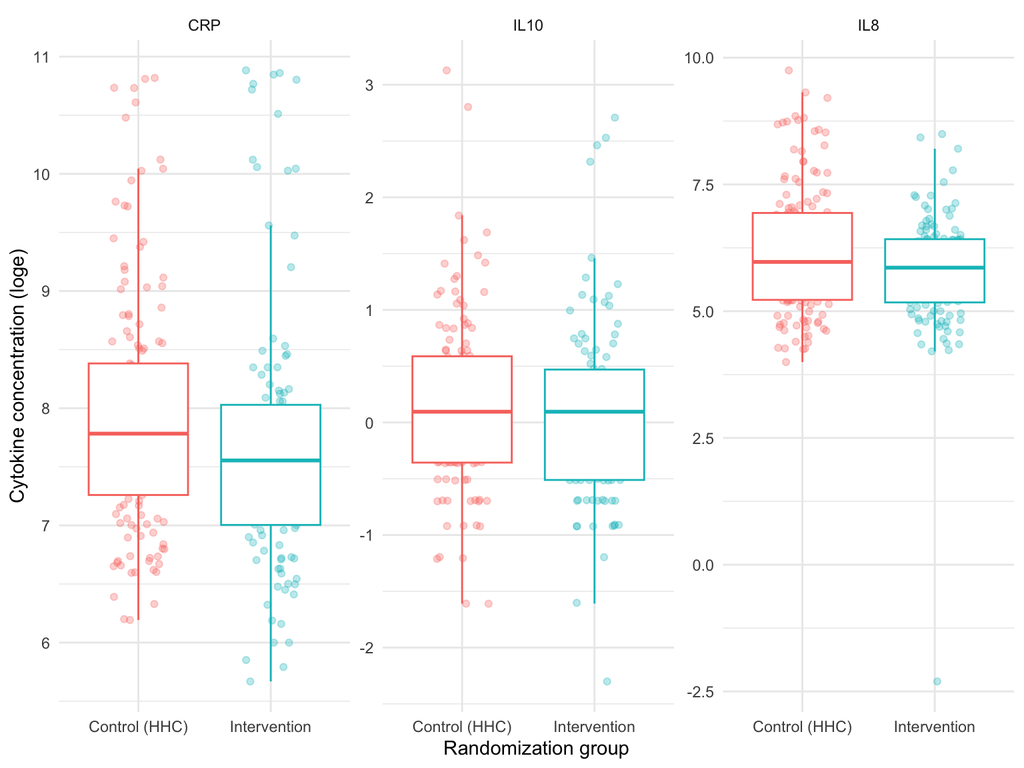

```r
long.data %>%
  ggplot(aes(x = randtx, y = log(concentration), colour = randtx)) + # make plot of cytokine concentration by group
    geom_jitter(alpha = 0.3, width = 0.2, size = 1.5) + # plot points
    geom_boxplot(outliers = F) + # make boxplot
    theme_minimal() + # use minimal theme
    facet_wrap(~ analyte_code, scales="free") + # facet the plot by the cytokine
    labs(x = "Randomization group", y = "Cytokine concentration (loge)", color = "") + # set the labels
    theme(legend.position="none") # remove the legend
```

## Cotinine vs cytokine concentration by randomization group

No real differences in $log_e$ transformed cytokine levels *or* $log_e$ transformed cotinine levels between randomization groups.

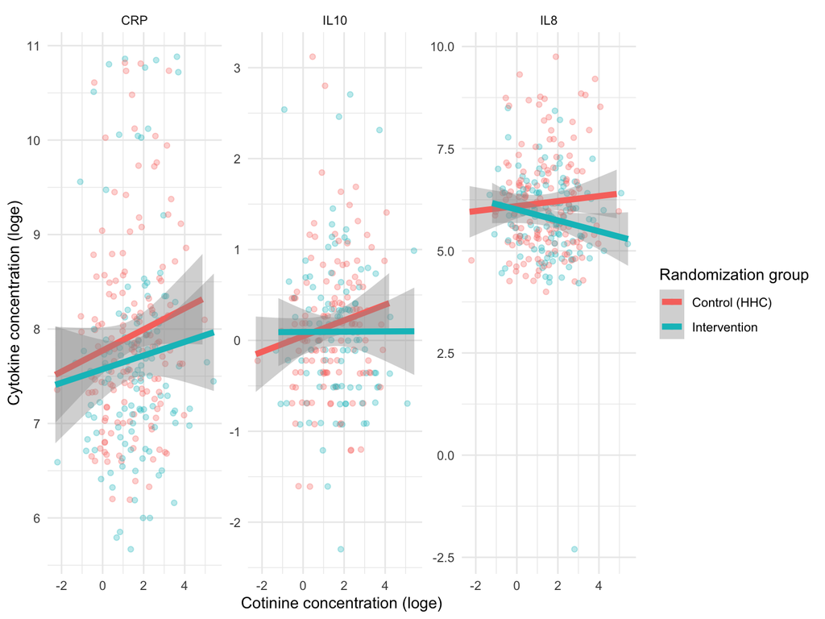

```r
long.data %>%
  ggplot(aes(x = log(cot_concentration), y = log(concentration), colour = randtx)) + # make plot of cotinine concentration vs cytokine concentration by group
    geom_jitter(alpha = 0.3, width = 0.2, size = 1.5) + # plot points
    geom_smooth(size = 2, method = "lm") + # plot linear relationship of best fit between x and y
    theme_minimal() + # use minimal theme
    facet_wrap(~ analyte_code, scales="free") + # facet the plot by the cytokine
    labs(x = "Cotinine concentration (loge)", y = "Cytokine concentration (loge)", color = "Randomization group")
```

## Cotinine vs cytokine concentration by smoker status (*smoke_epi_chld_exposed*)

Also, when we look at the relationship between $log_e$ transformed cytokine levels and $log_e$ transformed cotinine levels by epidemiological smoking status, we see that there are no real differences again. This, along with the cotinine data, strongly implies that the smoking survey questions aren’t super useful.

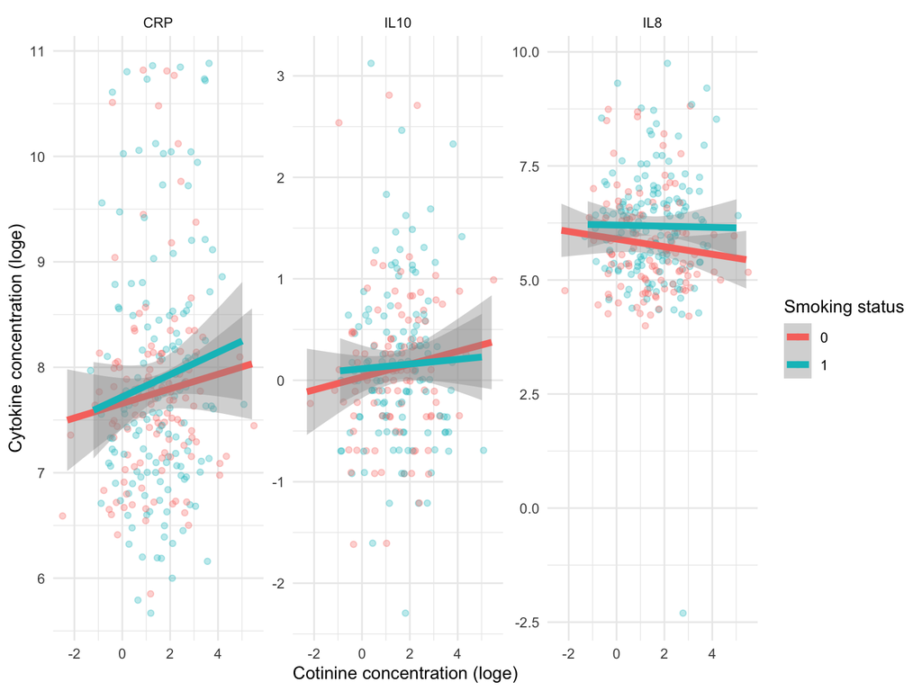

```r
long.data %>%
  drop_na(smoke_epi_chld_exposed) %>%
  ggplot(aes(x = log(cot_concentration), y = log(concentration), colour = smoke_epi_chld_exposed)) + # make plot of cotinine concentration vs cytokine concentration by group
    geom_jitter(alpha = 0.3, width = 0.2, size = 1.5) + # plot points
    geom_smooth(size = 2, method = "lm") + # plot linear relationship of best fit between x and y
    theme_minimal() + # use minimal theme
    facet_wrap(~ analyte_code, scales="free") + # facet the plot by the cytokine
    labs(x = "Cotinine concentration (loge)", y = "Cytokine concentration (loge)", color = "Smoking status")
```

## Cotinine vs cytokine concentration by e-cigarette use

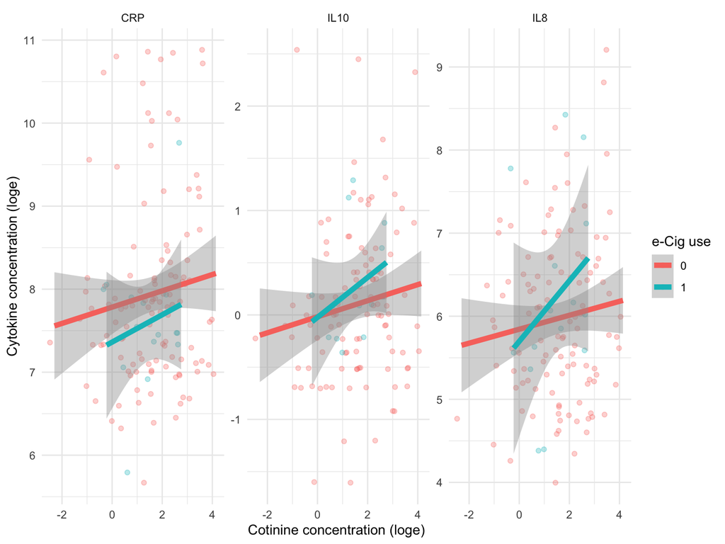

```r
long.data %>%
  drop_na(ecig_smoke) %>%
  ggplot(aes(x = log(cot_concentration), y = log(concentration), colour = ecig_smoke)) + # make plot of cotinine concentration vs cytokine concentration by group
    geom_jitter(alpha = 0.3, width = 0.2, size = 1.5) + # plot points
    geom_smooth(size = 2, method = "lm") + # plot linear relationship of best fit between x and y
    theme_minimal() + # use minimal theme
    facet_wrap(~ analyte_code, scales="free") + # facet the plot by the cytokine
    labs(x = "Cotinine concentration (loge)", y = "Cytokine concentration (loge)", color = "e-Cig use")
```

# Smoke Exposure Comparison at Baseline

## Cytokine levels

```r
wide.data %>%
  filter(time == "Baseline") |>
  select(CRP, IL10, IL8, cot_concentration, smoke_epi_chld_exposed) %>% # select variables
  drop_na(smoke_epi_chld_exposed) %>% # remove rows that are NA for smoke_epi_chld_exposed
  tbl_summary(by = smoke_epi_chld_exposed, # make the table, stratified by time
              percent = "column",  # use column percents for categorical variables
              type = list(`CRP`:`cot_concentration` ~ "continuous2"), # tell it to make multiple rows of stats output for continuous variables
              statistic = list(all_continuous() ~ c("{mean} ({sd})", "{median} ({p25}, {p75})", "{min}, {max}")), # select and format which stats I want
              missing_text = "Missing")  %>% # missing observations are marked as "missing"
  bold_labels() %>%
  add_overall(last = T) %>% # add overall column
  add_p(pvalue_fun = label_style_pvalue(digits = 3)) |> # add p-value for bivariate tests
  modify_spanning_header(
    all_stat_cols() ~ I("**Child exposed to smoke from > 0 cigarettes per day**")
  )
```

[output not shown]

<sup>1</sup> Wilcoxon rank sum test

## Cytokine levels stratified by sex

```r
wide.data %>%
  filter(time == "Baseline") |>
  select(sex, CRP, IL10, IL8, cot_concentration, smoke_epi_chld_exposed) %>% # select variables
  drop_na(smoke_epi_chld_exposed) %>% # remove rows that are NA for smoke_epi_chld_exposed
  tbl_strata(
    strata = sex, # further stratify the table by randomization group
    .tbl_fun =
      ~ .x %>%
      tbl_summary(by = smoke_epi_chld_exposed, # make the table, stratified by time
                  percent = "column",  # use column percents for categorical variables
                  type = list(`CRP`:`cot_concentration` ~ "continuous2"), # tell it to make multiple rows of stats output for continuous variables
                  statistic = list(all_continuous() ~ c("{mean} ({sd})", "{median} ({p25}, {p75})", "{min}, {max}")), # select and format which stats I want
                  missing_text = "Missing")  %>% # missing observations are marked as "missing"
      bold_labels() %>%
      add_overall(last = T) %>% # add overall column
      add_p(pvalue_fun = label_style_pvalue(digits = 3)) |> # add p-value for bivariate tests
      # .header = "**Child exposed to smoke from > 0 cigarettes per day: {strata}**, N = {n}"

      modify_spanning_header(
        all_stat_cols() ~ I("**Child exposed to smoke from > 0 cigarettes per day**")
      )
  )
```

| **Characteristic** | **male** **0** N = 33 | **male** **1** N = 47 | **male** **Overall** N = 80 | **male** **p-value**<sup>1</sup> | **female** **0** N = 36 | **female** **1** N = 41 | **female** **Overall** N = 77 | **female** **p-value**<sup>1</sup> |
| --- | --- | --- | --- | --- | --- | --- | --- | --- |
| CRP |  |  |  | 0.302 |  |  |  | 0.835 |
| Mean (SD) | 4,266 (6,826) | 7,306 (12,584) | 6,052 (10,647) |  | 4,607 (6,800) | 8,887 (13,600) | 6,886 (11,102) |  |
| Median (Q1, Q3) | 2,212 (1,506, 3,410) | 2,521 (1,525, 5,271) | 2,428 (1,516, 4,618) |  | 2,410 (1,869, 3,831) | 2,788 (1,283, 8,362) | 2,563 (1,584, 4,969) |  |
| Min, Max | 774, 36,734 | 328, 53,254 | 328, 53,254 |  | 696, 35,590 | 473, 52,082 | 473, 52,082 |  |
| IL10 |  |  |  | 0.507 |  |  |  | 0.522 |
| Mean (SD) | 2.36 (3.70) | 1.88 (3.30) | 2.07 (3.45) |  | 1.45 (2.13) | 1.11 (0.84) | 1.27 (1.58) |  |
| Median (Q1, Q3) | 1.30 (0.70, 2.30) | 1.20 (0.60, 1.80) | 1.20 (0.60, 1.90) |  | 0.95 (0.70, 1.30) | 0.85 (0.65, 1.25) | 0.90 (0.70, 1.30) |  |
| Min, Max | 0.20, 16.60 | 0.30, 22.70 | 0.20, 22.70 |  | 0.40, 12.60 | 0.20, 4.10 | 0.20, 12.60 |  |
| Missing | 2 | 0 | 2 |  | 4 | 5 | 9 |  |
| IL8 |  |  |  | 0.097 |  |  |  | 0.045 |
| Mean (SD) | 935 (1,445) | 1,137 (2,119) | 1,055 (1,868) |  | 578 (1,129) | 1,057 (1,569) | 840 (1,399) |  |
| Median (Q1, Q3) | 347 (145, 1,009) | 609 (253, 920) | 457 (200, 920) |  | 277 (179, 591) | 603 (248, 1,109) | 400 (188, 814) |  |
| Min, Max | 69, 5,913 | 72, 11,094 | 69, 11,094 |  | 109, 6,730 | 77, 6,960 | 77, 6,960 |  |
| Missing | 1 | 0 | 1 |  | 2 | 0 | 2 |  |
| cot_concentration |  |  |  | 0.336 |  |  |  | 0.675 |
| Mean (SD) | 11 (25) | 11 (23) | 11 (23) |  | 8 (8) | 9 (13) | 9 (11) |  |
| Median (Q1, Q3) | 4 (1, 8) | 4 (1, 13) | 4 (1, 10) |  | 5 (2, 12) | 4 (2, 11) | 5 (2, 11) |  |
| Min, Max | 0, 130 | 1, 150 | 0, 150 |  | 0, 25 | 1, 66 | 0, 66 |  |
| Missing | 1 | 0 | 1 |  |  |  |  |  |

<sup>1</sup> Wilcoxon rank sum exact test